# Penguin Assignment

## Results

Below is the output of the Pearson’s correlation test.

```
##
##  Pearson's product-moment correlation
##
## data:  body_mass_g and log_flipper_length
## t = 10.974, df = 117, p-value < 2.2e-16
## alternative hypothesis: true correlation is not equal to 0
## 95 percent confidence interval:
##  0.6104679 0.7908223
## sample estimates:
##       cor
## 0.7122052
```

The Pearson’s test revealed a strong positive correlation, indicating that as body mass increases, flipper length also tends to increase as well. The correlation coefficient (r) was 0.7122052 and showed a significant strong positive linear relationship between the two variables. The p value which was very small (p-value < 2.2e-16) indicates strong evidence against the null (as it is smaller than 0.05) meaning I can reject the null hypothesis confidently. The confidence interval suggests that the true correlation coefficient falls somewhere between 0.6104679 and 0.7908223, as these are positive values it further supports the interpretation that the correlation is strong and positive.

Below is the output of the linear model.

```r
#calling the model so that the outputs can be shown and interpreted
summary(gentoo_lm_unlogged)
```

```
##
## Call:
## lm(formula = flipper_length_mm ~ body_mass_g, data = gentoo_dataset)
##
## Residuals:
##      Min       1Q   Median       3Q      Max
## -12.0423  -2.7042   0.0293   3.1969   8.9577
##
## Coefficients:
##              Estimate Std. Error t value Pr(>|t|)
## (Intercept) 1.697e+02  4.366e+00   38.86   <2e-16 ***
## body_mass_g 9.341e-03  8.533e-04   10.95   <2e-16 ***
## ---
## Signif. codes:  0 '***' 0.001 '**' 0.01 '*' 0.05 '.' 0.1 ' ' 1
##
## Residual standard error: 4.649 on 117 degrees of freedom
## Multiple R-squared:  0.506,  Adjusted R-squared:  0.5017
## F-statistic: 119.8 on 1 and 117 DF,  p-value: < 2.2e-16
```

The slope (0.009341), which represents the body mass in this case, indicates that for every 1g increase in body_mass_g of a Gentoo penguin, their flipper length increases by 0.009341mm. The positive value indicates a significant positive linear relationship. The p value is very small (<2e-16) highlighting that the slope is statistically significant. As such we have strong evidence to reject the null hypothesis (which is that the slope is 0 and there is no relationship between penguin body mass and flipper length). This corroborates with my analysis in the Pearson’s test.

The standard error of the slope is 0.0008533 which is also very small and therefore indicates that the coefficient (slope) for the change in flipper length for one unit increase in body mass is very precise. This is also supported by the large t value of 10.95 that indicates the slope is a significant predictor of flipper length.The p value is <2e-16, indicating the slope for body mass is highly significant. The intercept value gives an estimate of flipper length when body mass is 0. In this case, it is biologically meaningless as penguin body mass would never be 0.

The adjusted R squared value is 0.5017 meaning that approximately 50.17% of the variation in flipper length can be explained by the body mass of the penguin. This suggests that it is a good model for predicting flipper length from body mass, however there are other factors contributing the remaining unexplained variation.

The F statistic of the model is 119.8 on 1 and 117 degrees of freedom. The p value of 2.2e-16 is extremely small, indicating that this F statistic is highly statistically significant. As such I am happy that my model has a good fit and that my analysis is valid.

### Results Figure:

The code chunk below creates a scatter plot with a fitted regression line that visualises the positive linear relationship between Gentoo body mass and flipper length.

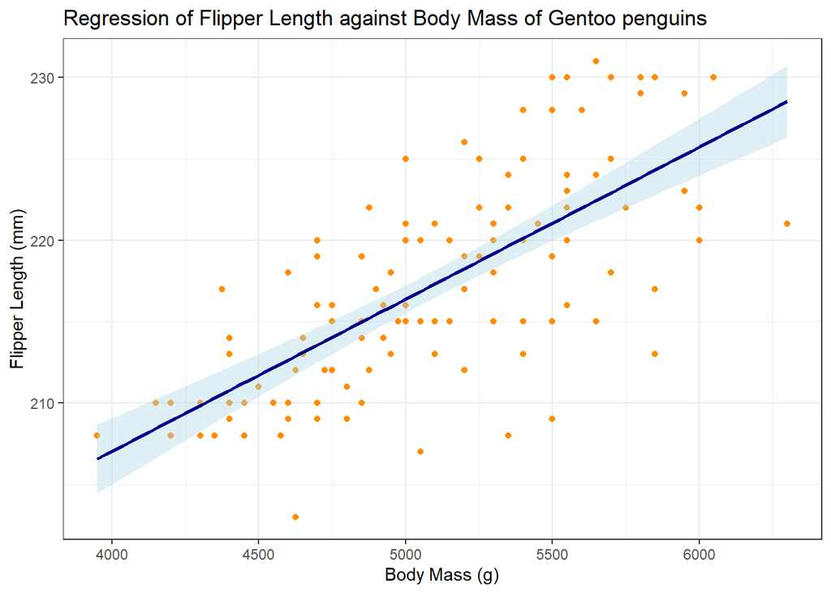

```r
gentoo_resultsplot <- gentoo_dataset %>%
  ggplot(aes(x = body_mass_g, y = flipper_length_mm)) +
  geom_point(
    color = "darkorange"  # Using a colour blind friendly colour for points
  ) +
  geom_smooth(
    method = "lm",
    se = TRUE,
    color = "darkblue",  # Colour blind friendly friendly colour for the regression line
    fill = "lightblue"   # Colour blind friendly colour for the confidence interval
  ) +
  labs(
    title = "Regression of Flipper Length against Body Mass of Gentoo penguins",
    x = "Body Mass (g)",
    y = "Flipper Length (mm)"
  ) +
  theme_bw()

print(gentoo_resultsplot)
```

```r
#Saving the initial scatter plot using svglite package. This allows the plot to be saved as a vector file so that if I need to scale it, the resolution will be maintained.

svglite("figures/gentoo_resultsplot.svg", # opening SVG device and saving in the 'figures' folder
        width = 5.9, height = 5.9) #specifying width and height

#closing the SVG (Scalable Vector Graphics) device
dev.off()
```

## Discussion

My pearson test analysis highlighted there is enough evidence that the null hypothesis can be rejected and that Gentoo body mass and flipper length have a significant correlation. The follow up linear model highlights that this is a significant positive linear relationship and that body mass is a significant predictor of flipper length. This is in line with what I would expect as it makes biological sense that flipper length should increase with body mass. Flippers are used as locomotive structures, enabling penguins to properly swim through water. As such, a larger body mass which generates more drag in water benefits from proportionally longer flippers which produce enough thrust for efficient swimming. A correlation and positive relationship in body mass and flipper length would also make sense in enabling balance and stability whilst swimming (mismatches in flipper length and bodymass may lead to energetically inefficient locomotion). Other penguins with a larger body mass and larger flippers, such as Emperor penguins, tend to dive deeper and swim longer distances for prey compared to Adelie penguins for example which have a smaller bodymass and flipper length [1]. As such, when thinking about whether penguins are specialised for diving, it seems likely that flipper length adapts with body mass to produce efficiency in the water.

Given that the adjusted R squared of the linear model is 0.5017, it indicates that the proportion of variation in flipper length that is explained by body mass is 50.17%. This is a fairly high value however the remaining 50% of unexplained variation indicates that there are other biological factors that explain the variation in flipper length. For example, even though the data looks at one species of penguin (Gentoo), it is likely there is still intraspecies variation which could account for the variation in flipper length. For example, individual genetic variation might result in some penguins having shorter or longer flippers simply due to their genetic makeup, and possibly even variation in epigenetic factors.

Furthermore, variation in diet quality and nutrition may also impact flipper length, with penguins that have access to more food resources likely developing maximally compared to those that don’t have access to the necessary nutrients during critical growth stages. In particular, I would be interested to explore how the changing ocean temperature is affecting the presence of their key food resources such as crustaceans, small fish and squid. For example, if these resources are migrating elsewhere due to changes in their own environments, are these penguins now having to learn to dive deeper or naviagate further from Biscoe island to forage. If this is the case then could their flipper lengths be evolving to adapt to these new physical demands?

Although all penguins recorded were from Biscoe island and likely shared a similar environment, it is possible that they still experienced differing micro habitats which could affect flipper length. For example, subtle environmental differences such as which side of the island they are nesting on may mean they have become adapted to specialised diving in differing currents. Stronger currents may require penguin flippers to be larger and sturdier compared to coasts of the island with a calmer current where they don’t have to deal with these physical demands during their lifetime. Additionally, although the data set records the Gentoo penguins as ‘adults’, we cannot assume each observation is the exact same age, and as such age is likely also a factor affecting flipper length. For example, younger adults might have smaller less developed flippers compared to older adults. Furthermore, sex could also be a factor contributing to variation if sexual dimorphism is present.

## Future Directions

Future analysis should involve the use of statistical methods such as ANCOVA or more complex linear regression where the co-variates considered above are accounted for. Although caution should be taken not to overfit a model, this will help gain a clearer understanding of the factors that contribute to the variation in flipper length we observe in Gentoo penguins.

A final comment is that in my Pearson test analysis I stated that I wanted to gain a holistic and comprehensive understanding of whether my data (the flipper length and body mass) was normally distributed. However, I only employed visual analysis (histograms and Q-Q plots). Whilst these are still incredibly useful to assess normality, they are limited in that they can be subjective and less precise in detecting very subtle deviations from normality. If I were to repeat this research in future analysis, I would suggest conducting parametric tests such as the Shapiro Wilk test. This will give a quantifiable understanding of whether the distribution significantly deviates from a normal distribution, and can help to further confirm my observations.

## Conclusion

To conclude, the main aim of this analysis pipeline was to investigate if there was a correlation between Gentoo body mass and flipper length. The Pearson’s test highlighted a significant correlation between penguin body mass and flipper length. This was followed by a linear model that highlighted this correlation as a significant positive linear relationship and body mass is a significant predictor of flipper length. The model did however suggest there are other biological factors which contribute to the variation we see. As such it is critical that future work considers what these are and to what extent they contribute to the observed variation.

### References

[1] Wienecke, B., Robertson, G., Kirkwood, R. et al. Extreme dives by free-ranging emperor penguins. Polar Biol 30, 133–142 (2007). https://doi.org/10.1007/s00300-006-0168-8

## QUESTION 3: Open Science

### a) GitHub

*Upload your RProject you created for **Question 2** and any files and subfolders used to GitHub. Do not include any identifiers such as your name. Make sure your GitHub repo is public.*

*GitHub link:* https://github.com/ZigiButtercup/PenguinsAssignment36

*You will be marked on your repo organisation and readability.*

### b) Share your repo with a partner, download, and try to run their data pipeline.

*Partner’s GitHub link:* https://github.com/daisyjeans/Reproducible-Figures

*You **must** provide this so I can verify there is no plagiarism between you and your partner.*

### c) Reflect on your experience running their code. (300-500 words)

- *What elements of your partner’s code helped you to understand their data pipeline?*

My partner’s code included lots of elements to help me understand their code. Firstly, for the most part, they separated their code into code chunks rather than writing one huge chunk of code. This meant that I could run each chunk separately and see the output from that chunk before moving on to the next. This really helped to understand which part of the code is doing what and what it is producing. Secondly, my partner used hashtags to provide comments explicitly explaining what every line of code does. They didn’t just comment what a chunk was doing, they commented each line within the chunk to provide a really detailed explanation. My partner also provided a read.me file in their repository which helped to gain an initial understanding of what the project was about and what was in the important files. In most of their code they also used tabs and indentations which made the code more readable. There was just one part where for some reason this didn’t format in the same way (explained below). Finally, my partner also explained in plain text what the chunk was about to do by saying ‘here I…’ and then having the chunk below this. They also labelled all their chunks which meant I knew the main idea of what each was doing. Overall, I think they made their code so it could be well understood.

- *Did it run? Did you need to fix anything?*

It ran the first time with no issues.

- *What suggestions would you make for improving their code to make it more understandable or reproducible, and why?*

Making it more understandable: although the chunks were mainly fine, there were was one chunk that I feel could have possibly been split up for better readability. The density plots for body mass and flipper length were in one large chunk but I feel if they had been separate then it would be more easy to run the first chunk and view the corresponding plot then run the second chunk and view the corresponding plot. Furthermore, my partner performed the statistical test inside the section about results. To improve readability it may have been worth performing the stats test inside the statistical methods section. Additionally, the formatting of the code producing the body mass density plot could have been made use of indentations and tabs, rather than a big block paragraph, to improve readability. The section of code below does this and it reads much more easily. My partner also included the initial exploratory plot at the beginning of the results section. I feel it would have possibly made more sense to do this near the introduction or around the hypotheses section so that we can gain a visual understanding of what the code is exploring at the very beginning rather than towards the end. Overall, I would say that my partner’s code seems really reproducible as she has used renv, github and relative filepaths etc.

- *If you needed to alter your partner’s figure using their code, do you think that would be easy or difficult, and why?*

Parts would be easy and parts would be difficult. For the most part, the code is formatted really nicely with tabs and indentations, making it easy to identify where ggplot() and other functions start and end, and as such edit these if need be. However, the body mass density plot, as mentioned above had a more difficult paragraph-like format to read because the comments spilled over onto the next line and fit between the lines of code. This might make it slightly harder to locate parts of the code and edit on first glance. Furthermore, my partners code for plotting the graphs was all inside the main script which in this case made it easy to immediately locate and understand what I would want to change. However, I would suggest that if my partner was ever creating a script with lots of graphs, it would be beneficial to turn the code that plots the graph into a function, and then keep it in another separate functions folder, for example called ‘plotting.R’. This would prevent a script from become excessively long and cluttered, and it also means that once again reproducibility is improved as if a plotting function needs to be changed, this can be done in the separate file and will then be reflected automatically in the main script if source() is used.

### d) Reflect on your own code based on your experience with your partner’s code and their review of yours. (300-500 words)

- *What improvements did they suggest, and do you agree?*

My partner said that overall my code was highly organised however there were some areas where a few extra annotations could have been useful. For example at the start of the script in the chunk with library() in it I didn’t comment out explicitly that this was opening the packages. I agree I should have done this as in terms of reproducibility, my code is supposed to be accessible to everyone and even though I know what library() means, others may not. They also said abbreviations could be confusing as at one point I said ‘homo’ in a comment rather than homoscedasticity. I completely agree next time it would be beneficial not to abbreviate. Additionally my partner highlighted a piece of redundant code: colnames(penguins_raw) which was repeated. I agree this is distracting and wasn’t absolutely necessary. Finally my partner said that the names of my plots could have been clearer. I named them gentoo_explorplot and gentoo_resultsplot. I think gentoo_exploratoryplot would have been better, but my partner also said specifying the results plot as gentoo_scatterplot could be better. I don’t agree with this simply because my exploratory figure was also a scatterplot so it will create confusion.

- *What did you learn about writing code for other people?*

When writing code for others I have learnt that no matter the coding capabilities of the reader, it is always critical to use comments to spell out the purpose of what I am doing and why. This means that individuals can follow the code when first reading it but also if they (or myself) want to come back to it years later. It also enhances reproducibility as if others are using my code and data set but can’t reproduce the same results, a precisely annotated script increases the likelihood of finding errors. Furthermore, the use of a Read Me file is useful for explaining to others how to use the script. I also learnt that the organisation of code is important in creating a good user experience; use of a consistent style and codes that are separated into clear labelled chunks are much more approachable compared to all lines of code within a single chunk block. Separate chunks which can be run separately also allow easier detection of errors, increasing reproducibility. Additionally, I’ve learnt that using raw file paths should be avoided, and instead relative file paths using the here::here() function are optimal for reproducibility. Finally, I gained an understanding that when writing code for others, the use of tools such as renv is important for managing package dependencies, and version control platforms such as Github are helpful when sharing code with others and tracking changes. Overall I enjoyed the experience and now feel more confident that I can produce reproducible coding projects now!